# Sensitivity Analysis for Pueblo

Project: Differential Gene Expression and Pulmonary Function in Vaping LatinX Adolescents Analyst: Trent Hawkins Investigator(s): Sunita Sharma, MD Report generated: June 13, 2022

# Introduction

In the generalized results report, it appeared that Sample 12 may not have been sufficiently corrected by the DESeq2 model as suggested by the RLE and PCA plots produced by RUVSeq (see “Exploratory Report” and “Differential Expression Results”). This short report will perform a sensitivity analysis for Sample 12 and compare the results for the *Vape Status* model with results when Sample 12 is removed from the model.

# Methods

To assess the difference in model outputs, the following model was fit in DESeq2 1.34.0 both with and without Sample 12. Likelihood Ratio Tests (LRTs) were implemented to test for gene significance and corrected with FDR = 0.05. For the purpose of this report, the model containing Sample 12 will be referred to as *Model A* and the model with sample 12 removed will be referred to as *Model B*.

$$Full \ Model \\ raw \ read \ count \sim
vape \ status + recruitment \ center + sex + age + ruv_1 +
ruv_2$$

$$Reduced \ Model \ (Vape \ Status) \\ raw
\ read \ count \sim recruitment \ center + sex + age + ruv_1 +
ruv_2$$

To assess the difference in the models, the results will focus on genes with relatively low variability. To achieve a stable subset, a cutoff value for |Log<sub>2</sub>(Fold-Change)| will be selected through visual inspection, and then the top 100 genes will be subset from Model A. For the subset of genes, the report will present:

1. A Venn Diagram summarizing the top 100 genes in each model.
2. Visualizations comparing |Log<sub>2</sub>(Fold-Change)| estimates between the two models.
3. A short table for the top 10 genes and their estimates in both models.

# Results

The top 100 genes determined by the FDR-adjusted p-value were subset from Model A to compare to Model B. This comparison shows that the top 100 genes in Model A are identical to the top 100 genes in Model B. Some of these genes have very small estimates, which may lead to an extremely large % change, even if the actual amount of change is relatively small. To find a more stable subset of genes, Figure 1 presents a range of possible cutoff values and how many genes in the top 100 are replaced compared to a model with no cutoff.

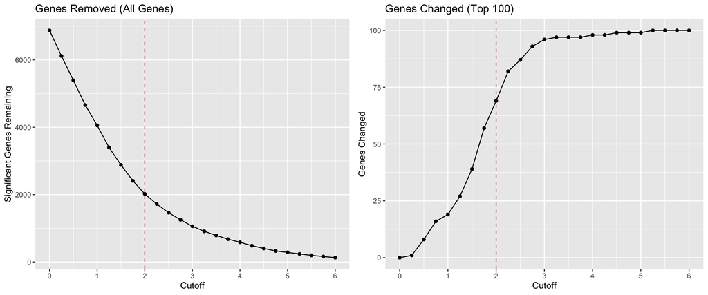

```r
#############Read in results###################
modA_res <- read_csv(here("DataProcessed/de_full/full_vape_res_2022_05_01.csv"))
modB_res <- read_csv(here("DataProcessed/de_pueblo_sensitivity/vape_res_pblo_2022_06_13.csv"))

#############Join results and get top 100 genes###################
AB_res <- left_join(modA_res, modB_res, by = c("ensg", "gene_name", "gene_type"), suffix = c(".modA", ".modB"))
#no cutoff
top_100_genes_AB <- AB_res %>% arrange(padj.modA) %>% .[1:100,]

######################### Filter for log-fold change (check) ###############################

check_lf_cutoff <- function(de_res) {
  top_100 <- de_res %>% arrange(padj) %>% .[1:100,]
  cutoff_seq <- seq(0,6,0.25)
  cutoff_res <- NULL
  top_100_res <- NULL
  for (cutoff in cutoff_seq) {
    #How does it change all of the genes?
    num_genes <- nrow(de_res %>%
                        filter(padj < 0.05) %>%
                        filter(abs(log2FoldChange) > cutoff))
    cutoff_res <- append(cutoff_res, num_genes)

    #How does it change the top 100 genes?
    top_100_change <- 100 - nrow(top_100 %>%
                        filter(abs(log2FoldChange) > cutoff))
    top_100_res <- append(top_100_res, top_100_change)}

  result <- tibble(Cutoff = cutoff_seq,
                   Genes = cutoff_res,
                   Genes_100 = top_100_res)
  return(result)
}

sample_12_cutoff <- check_lf_cutoff(modA_res)

allgenes_cutoff <- sample_12_cutoff %>%
  ggplot(aes(x = Cutoff, y = Genes)) +
  geom_point() +
  geom_line() + geom_vline(xintercept = 2, col = 'red', linetype = 2) +
  scale_x_continuous(breaks = seq(0,6,1)) +
  labs(y = "Significant Genes Remaining",
       title = "Genes Removed (All Genes)")

top_100_cutoff <- sample_12_cutoff %>%
  ggplot(aes(x = Cutoff, y = Genes_100)) +
  geom_point() +
  geom_line() +
  geom_vline(xintercept = 2, linetype = 2, col = 'red') +
  scale_x_continuous(breaks = seq(0,6,1)) +
  labs(y = "Genes Changed",
       title = "Genes Changed (Top 100)")

ggarrange(allgenes_cutoff, top_100_cutoff, nrow = 1, ncol = 2)
```

Figure 1 shows A) the number of genes removed from all significant genes in Model A and B) the number of genes that change in the subset of the top 100 genes. It should be noted that those genes are still significant, but not included in the range of the cutoff demonstrated. In the interest of obtaining a smaller subset of genes to work with, we will use a cutoff of an |Log<sub>2</sub>(Fold-Change)| of 2. At this cutoff value, 2,022 genes remain in the overall results from Model A, and 69 genes changed in the composition of the top 100 genes.

```r
#implement cutoff
AB_res_cutoff <- AB_res %>%
  filter(abs(log2FoldChange.modA) > 2) %>%
  arrange(padj.modA)

#Get the top 100 genes
cutoff_100 <- AB_res_cutoff[1:100,]

#number of genes included both before and after cutoff implemented
genes_kept <- as.numeric(sum(top_100_genes_AB$ensg %in% cutoff_100$ensg))

#genes changed
genes_changed <- 100 - genes_kept

#Make Tidy Results
cutoff_100_res <- cutoff_100 %>%
  dplyr::mutate(fold_change_diff = log2FoldChange.modB - log2FoldChange.modA,
                fold_change_diff_p = (log2FoldChange.modB - log2FoldChange.modA)/log2FoldChange.modA) %>%
  dplyr::select(ensg, gene_name, gene_type, log2FoldChange.modA, log2FoldChange.modB, fold_change_diff, fold_change_diff_p, padj.modA, padj.modB) %>%
  dplyr::rename(Gene = ensg,
                Gene_Name = gene_name,
                Gene_Type = gene_type,
                Estimate_A = log2FoldChange.modA,
                Estimate_B = log2FoldChange.modB,
                Estimate_Difference = fold_change_diff,
                FDR_A = padj.modA,
                FDR_B = padj.modB)


# #############Venn Diagram##################
# #Get significant pvals
# pval_match <- AB_res_cutoff %>%
#   dplyr::mutate(modA_sig = if_else(FDR_A < 0.05 & FDR_B > 0.05, T,F),
#                 modB_sig = if_else(FDR_B < 0.05 & FDR_A > 0.05, T,F),
#                 modAB_sig = if_else(FDR_B < 0.05 & FDR_A < 0.05, T,F),
#                 neither_sig = if_else(FDR_A > 0.05 & FDR_B > 0.05,T, F)) %>%
#   dplyr::arrange(FDR_A)
#
# cutoff_100 <- pval_match[1:100,]
#
# #Get significant gene names for each model
# modA_sig_genes <- pval_match[pval_match$FDR_A < 0.05,]$Gene
# modB_sig_genes <- pval_match[pval_match$FDR_B < 0.05,]$Gene
#
# #Set color palatte
# venn_color <- brewer.pal(3,"Pastel2")
#
# Make Venn Diagram
# VennDiagram::venn.diagram(x = list(modA_sig_genes,modB_sig_genes),
#                           category.names = c("Model A","Model B"),
#                           filename = here("Reports/figures/venn_diagrams/sample12_sens_venn.png"),
#                           lwd = 2,
#                           fill = c(venn_color[1],venn_color[3]))
```

### Figure 2: Total Significant Genes in Models A & B

The top 100 significant genes in models A & B are identical both before and after the selected cutoff value (|Log<sub>2</sub>(Fold-Change)| > 2). A Venn Diagram of these would be trivial (a single circle), so Figure 2 shows the breakdown of the significant genes in Models A and B.

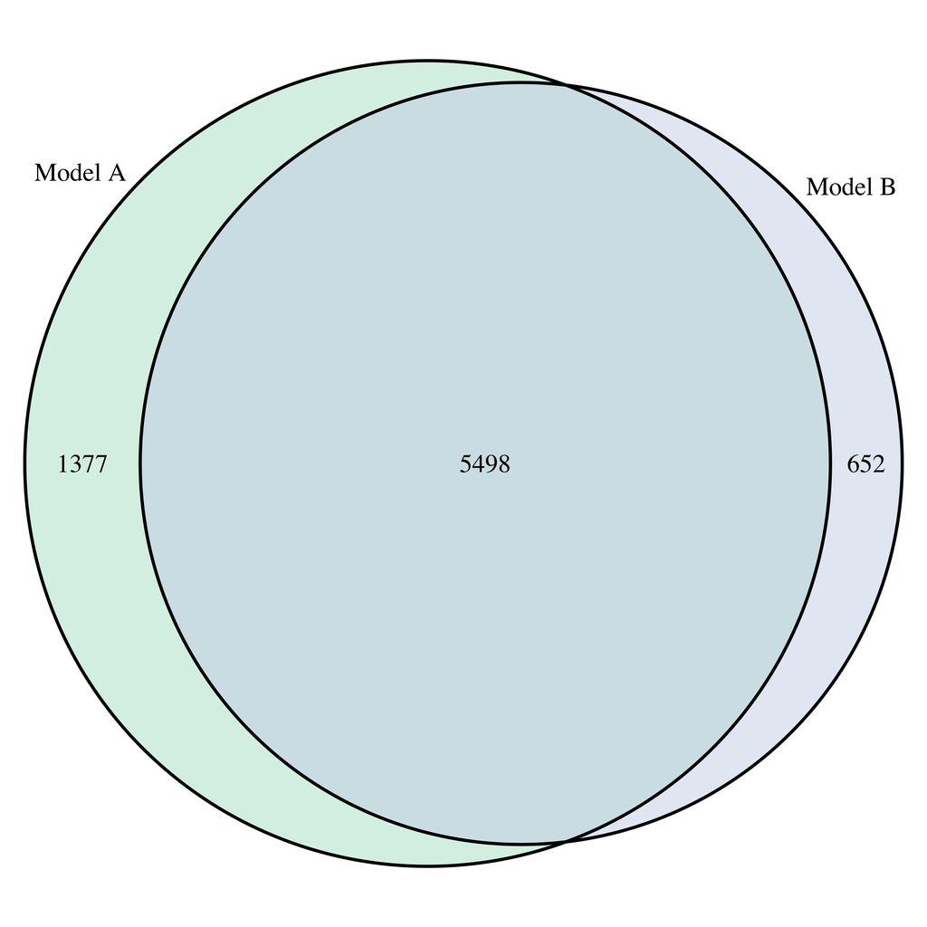

### Figure 3: Difference in Log<sub>2</sub>(Fold-Change) (Top 100 Genes)

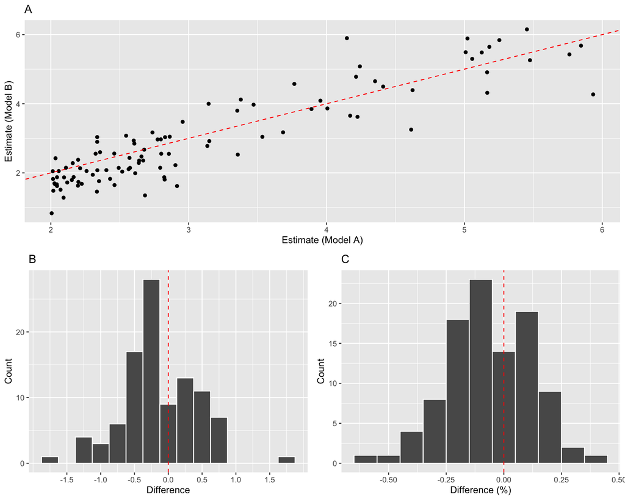

```r
#############Plots of change in log2fc##################
#Scatter Plot
change_scatter <- cutoff_100_res %>%
  ggplot(aes(x = Estimate_A, y = Estimate_B)) +
  geom_point(col = case_when(cutoff_100_res$Estimate_A > 0 & cutoff_100_res$Estimate_B < 0 ~ 'red',
                             cutoff_100_res$Estimate_A < 0 & cutoff_100_res$Estimate_B > 0 ~ 'red',
                             TRUE ~ 'black')) +
  geom_abline(intercept = 0, slope = 1, linetype = 2, col = 'red')+
  labs(x = "Estimate (Model A)",
       y = "Estimate (Model B)",
       title = "A")

#Histogram of difference
diff_hist <- cutoff_100_res %>%
  ggplot(aes(x = Estimate_Difference)) +
  geom_histogram(col = 'white', binwidth = 0.25) +
  scale_x_continuous(breaks = seq(-1.5, 1.5, 0.5)) +
  geom_vline(xintercept = 0, linetype = 2, col = 'red') +
  labs(x = "Difference",
       y = "Count",
       title = "B")

#Histogram of % change
p_diff_hist <- cutoff_100_res %>%
  ggplot(aes(x = fold_change_diff_p)) +
  geom_histogram(col = 'white', binwidth = 0.1) +
  scale_x_continuous(breaks = seq(-1, 1, 0.25)) +
  geom_vline(xintercept = 0, linetype = 2, col = 'red') +
  labs(x = "Difference (%)",
       y = "Count",
       title = "C")

ggarrange(change_scatter, ggarrange(diff_hist, p_diff_hist, ncol = 2, nrow = 1, legend = "none"), nrow = 2, common.legend = T, legend = "bottom")
```

*Table 2: Top 10 Significant Genes Models A & B*

```r
cutoff_100_res[1:10,] %>%
  mutate(fold_change_diff_p = fold_change_diff_p*100) %>%
  select(Gene, Gene_Name, Gene_Type, Estimate_A, Estimate_B, Estimate_Difference, fold_change_diff_p, FDR_A, FDR_B) %>%
  mutate(FDR_A = if_else(FDR_A < 0.001, "< 0.001", as.character(round(FDR_A,3))),
         FDR_B = if_else(FDR_B < 0.001, "< 0.001", as.character(round(FDR_B,3)))) %>%
  dplyr::rename("Ensemble ID" = Gene,
                "Gene Name" = Gene_Name,
                "Gene Type" = Gene_Type,
                "Estimate (Mod A)" = Estimate_A,
                "Estimate (Mod B)" = Estimate_B,
                "Estimate Difference" = Estimate_Difference,
                "Esimate Difference (%)" = fold_change_diff_p,
                "FDR (Mod A)" = FDR_A,
                "FDR (Mod B)" = FDR_B) %>%
  kablize(.,digits = 3)
```

| Ensemble ID | Gene Name | Gene Type | Estimate (Mod A) | Estimate (Mod B) | Estimate Difference | Esimate Difference (%) | FDR (Mod A) | FDR (Mod B) |
| --- | --- | --- | --- | --- | --- | --- | --- | --- |
| ENSG00000120063.10 | GNA13 | protein_coding | 2.571 | 2.433 | -0.137 | -5.336 | < 0.001 | < 0.001 |
| ENSG00000147416.11 | ATP6V1B2 | protein_coding | 2.096 | 1.870 | -0.226 | -10.778 | < 0.001 | < 0.001 |
| ENSG00000189067.14 | LITAF | protein_coding | 2.856 | 2.551 | -0.305 | -10.690 | < 0.001 | < 0.001 |
| ENSG00000131873.7 | CHSY1 | protein_coding | 2.564 | 2.109 | -0.455 | -17.756 | < 0.001 | < 0.001 |
| ENSG00000197081.16 | IGF2R | protein_coding | 2.159 | 2.282 | 0.123 | 5.678 | < 0.001 | < 0.001 |
| ENSG00000173281.5 | PPP1R3B | protein_coding | 2.826 | 1.806 | -1.019 | -36.076 | < 0.001 | < 0.001 |
| ENSG00000177885.15 | GRB2 | protein_coding | 2.026 | 1.696 | -0.331 | -16.329 | < 0.001 | < 0.001 |
| ENSG00000138002.16 | IFT172 | protein_coding | 2.606 | 2.847 | 0.241 | 9.257 | < 0.001 | < 0.001 |
| ENSG00000196954.14 | CASP4 | protein_coding | 2.057 | 2.052 | -0.005 | -0.242 | < 0.001 | < 0.001 |
| ENSG00000141298.19 | SSH2 | protein_coding | 2.093 | 1.283 | -0.809 | -38.666 | < 0.001 | < 0.001 |

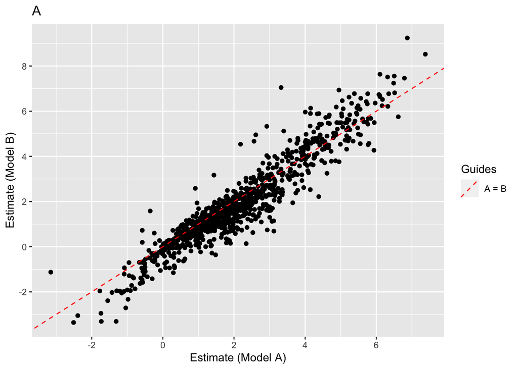

```r
#Get the top 2000 genes
top_1000 <- AB_res[1:1000,]

#Make Tidy Results
res_1000 <- top_1000 %>%
  dplyr::mutate(fold_change_diff = log2FoldChange.modB - log2FoldChange.modA,
                fold_change_diff_p = (log2FoldChange.modB - log2FoldChange.modA)/log2FoldChange.modA) %>%
  dplyr::select(ensg, gene_name, gene_type, log2FoldChange.modA, log2FoldChange.modB, fold_change_diff, fold_change_diff_p, padj.modA, padj.modB) %>%
  dplyr::rename(Gene = ensg,
                Gene_Name = gene_name,
                Gene_Type = gene_type,
                Estimate_A = log2FoldChange.modA,
                Estimate_B = log2FoldChange.modB,
                Estimate_Difference = fold_change_diff,
                FDR_A = padj.modA,
                FDR_B = padj.modB)

#Scatter Plot
change_scatter <- res_1000 %>%
  ggplot(aes(x = Estimate_A, y = Estimate_B)) +
  geom_point() +
  geom_abline(aes(intercept = 0, slope = 1, col = "A = B"), linetype = 2)+
  labs(x = "Estimate (Model A)",
       y = "Estimate (Model B)",
       title = "A")+
  scale_x_continuous(breaks = seq(-10,10,2)) +
  scale_y_continuous(breaks = seq(-10,10,2)) +
  scale_color_manual(name = "Guides", values = c("A = B" = "red"))
change_scatter
```

Figure 5 similarly visualizes the trend by plotting -log<sub>10</sub>(p-value) for each of the models plotted against each other.

### Figure 5: -log<sub>10</sub>(p-value) Model A vs. Model B

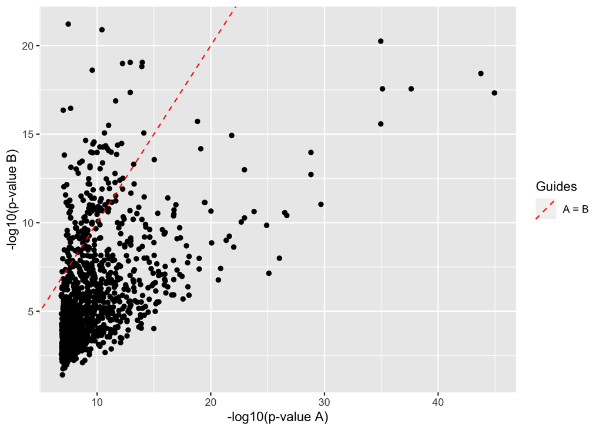

```r
top_1000 %>%
  ggplot(aes(x = -log10(padj.modA), y = -log10(padj.modB))) +
  geom_point() +
  geom_abline(aes(intercept = 0, slope = 1, col = 'A = B'), linetype = 2)+
  scale_color_manual(name = "Guides", values = c("A = B" = "red")) +
  labs(x = "-log10(p-value A)",
       y = "-log10(p-value B)")
```

# Conclusion